# PROCESOS DE SELECCIÓN DE VARIABLES EXPLICATIVAS EN MODELOS ESTADÍSTICOS (SELECTION PROCESSES OF EXPLANATORY VARIABLES IN STATISTICAL MODELS)

JOSÉ M. GÓMEZ

23/10/2021

# PROCESO DE SELECCIÓN DE VARIABLES EXPLICATIVAS

## Introducción: Sobre la necesidad de un proceso de selección de predictores

Usualmente se tiene interés en explicar los datos de la forma más simple, lo cual en el contexto de la teoría de las probabilidades (especialmente en la teoría bayesiana de probabilidades) se conoce como el *principio de parsimonia*, el cual está inspirado en el principio filosófico conocido como *navaja de Ockham*, la cual establece que en igualdad de condiciones la explicación más simple suele ser la más probable. El principio de parsimonia adopta diferentes formas según el área de estudio del análisis inferencial en el que se encuentre un investigador. Por ejemplo, una parametrización parsimoniosa es aquella que usa el número óptimo de parámetros para explicar el conjunto de datos de los que se dispone, pero “parsimonia” también puede referirse a modelos de regresión parsimoniosos, es decir, modelos que utilizan como criterio de optimización emplear la mínima cantidad de coeficientes de regresión para explicar una respuesta condicional Y. El principio de parsimonia, los procesos matemáticos de optimización regidos por el criterio de alcanzar un mínimo y la navaja de Ockham son un mismo tipo de lógica aplicado en escalas de la existencia (que podríamos llamar en general “materia”, como lo hace Landau en sus curso de física teórica) cualitativamente diferentes. La historia de la Filosofía demuestra que el único sistema que podría ser aplicado así exitosamente es el sistema hegeliano (lo que obedece a que parcialmente sigue la lógica de la existencia misma, como han demostrado Marx, Engels, Lenin, Levins, Lewontin y el mismo Hegel en su extensa obra). ¿Cómo es posible la vinculación en distintas escalas cualitativas de la realidad del principio de la navaja de Ockham? A que todas esas ideas responden a la escuela filosófica de Ockham, que era la escuela nominalista. Retomando lo que señalan (Rosental & Iudin. Diccionario Filosófico, Editorial Tecolut, 1971. p.341; véase https://www.filosofia.org/enc/ros/nom.htm), el nominalismo fue una corriente de la filosofía medieval que consideraba (ya es una escuela extinta) que los conceptos generales tan sólo son nombres de los objetos singulares. Los nominalistas afirmaban que sólo poseen existencia real las cosas en sí, con sus cualidades individuales (es decir, las generalizaciones para ellos no tenían valor gnoseológico en sí mismas sino como recurso gnoseológico). Los nominalistas van más allá, planteando que las generalizaciones no sólo no existen con independencia de los objetos particulares (esta afirmación en correcta, lo que no es correcto es pensar que lo inverso sí es cierto), sino que ni siquiera reflejan las propiedades y cualidades de las cosas. El nominalisto se hallaba indisolublemente vinculado a las tendencias materialistas, ya que reconocía la prioridad de la cosa y el carácter secundario del concepto. Por supuesto, las generalizaciones aunque menos reales que los objetos particulares (y de ahí la sujeción de la teoría a la práctica en un concepto que las une conocido en la teoría marxista como *praxis*) no deja por ello de ser real en cuanto busca ser una representación aproximada (a largo plazo cada vez más aproximada a medida se desarrollan las fuerzas productivas) de la estructura general (interna y externa, métrica y topológica) común que tienen tales fenómenos naturales o sociales. Marx señaló que el nominalismo fue la primera expresión del materialismo de la Edad Media. Con todo, los nominalistas no comprendían que los conceptos generales reflejan cualidades reales de cosas que existen objetivamente y que las cosas singulares no pueden separarse de lo general, pues lo contienen en sí mismas (y esto no tiene un carácter únicamente marxista, sino que incluso el célebre formalista David Hilbert señaló, según la célebre biógrafa de matemáticos Constance Reid que “The art of doing mathematics consists in finding that special case which contains all the germs of generality”). Así, el defecto fundamental de la navaja de Ockham es el no considerar algún conjunto de restricciones que complementen al criterio de selección de la explicación basado en que sea la idea más simple. Como se señala en https://www.wikiwand.com/en/Occam%27s_razor, “En química, la navaja de Occam es a menudo una heurística importante al desarrollar un modelo de mecanismo de reacción (…) Aunque es útil como heurística en el desarrollo de modelos de mecanismos de reacción, se ha demostrado que falla como criterio para seleccionar entre algunos modelos publicados seleccionados (…) En este contexto, el propio Einstein expresó cautela cuando formuló la Restricción de Einstein:”Difícilmente se puede negar que el objetivo supremo de toda teoría es hacer que los elementos básicos irreductibles sean tan simples y tan pocos como sea posible sin tener que renunciar a la representación adecuada de un dato único de experiencia”.” La clave en la expresión anterior de Einstein es “sin tener que renunciar a…”, lo que se cristaliza nítidamente en una frase que señala la fuente citada es atribuida a Einstein, pero no ha sido posible su verificación: “Todo debe mantenerse lo más simple posible, pero no lo más simple”. Como se verifica en https://www.statisticshowto.com/parsimonious-model/, en general, existe un *trade-off* entre la bondad de ajuste de un modelo y la parsimonia: los modelos de baja parsimonia (es decir, modelos con muchos parámetros) tienden a tener un mejor ajuste que los modelos de alta parsimonia, por lo que es necesario buscar un equilibrio.

La parsimonia estadística es deseada porque un mínimo de coeficientes de regresión implica un mínimo de variables y un mínimo de estos implica un mínimo de variables explicativas, lo que puede ser útil en casos de que exista colinealidad entre las variables explicativas, así como también permite ahorrar tiempo y dinero en lo relativo a la inversión de recursos destinada al estudio, aunque no necesariamente garantice que en general (considerando el impacto posterior de las decisiones tomadas con base en el estudio y otros factores) se ahorre tiempo y dinero.

## Modelos Jerárquicos

Existen diferentes tipos de modelos jerárquicos. Los hay de diferente tipo, algunos más complejos que otros (complejidad a nivel teórico, matemático y computacional); ejemplos de tales modelos son las mixturas de probabilidad y se pueden estudiar en https://marxianstatistics.files.wordpress.com/2020/12/sobre-los-estimadores-de-bayes-el-analisis-de-grupos-y-las-mixturas-gaussianas-isadore-nabi.pdf. Aquí se tratará con modelos jerárquicos más simples, como los abordados en (Kutner, Nachtsheim, Neter & Li. p.294-305).

Como señalan los autores referidos en la p.294., los modelos de regresión polinomial tienen dos tipos básicos de usos: 1. Cuando la verdadera función de respuesta curvilínea es de hecho una función polinomial. 2. Cuando la verdadera función de respuesta curvilínea es desconocida (o compleja), pero una función polinomial es una buena aproximación a la función verdadera. El segundo tipo de uso, donde la función polinomial se emplea como una aproximación cuando se desconoce la forma de la verdadera función de respuesta curvilínea, es muy común. Puede verse como un enfoque no paramétrico para obtener información sobre la forma de la función que modela la variable de respuesta. Un peligro principal en el uso de modelos de regresión polinomial es que las extrapolaciones pueden ser peligrosas con estos modelos, especialmente en aquellos con términos de orden superior, es decir, en aquellos cuyas potencias sean iguales o mayores a 2. Los modelos de regresión polinomial pueden proporcionar buenos ajustes para los datos disponibles, pero pueden girar en direcciones inesperadas cuando se extrapolan más allá del rango de los datos.

Así, como señalan los autores referidos en la p.305, el uso de modelos polinomiales no está exento de inconvenientes. Estos modelos pueden ser más costosos en grados de libertad que los modelos no-lineales alternativos o los modelos lineales con variables transformadas. Otro inconveniente potencial es que puede existir multicolinealidad grave incluso cuando las variables predictoras están centradas. Una alternativa al uso de variables centradas en la regresión polinomial es usar polinomios ortogonales. Los polinomios ortogonales están no-correlacionados, puesto que la ortogonalidad de sus términos implica independencia lineal entre los mismos. Algunos paquetes de computadora usan polinomios ortogonales en sus rutinas de regresión polinomial y presentan los resultados ajustados finales en términos tanto de los polinomios ortogonales como de los polinomios originales. Los polinomios ortogonales se discuten en textos especializados como (Drapper & Smith, Applied Linear Regression). A veces, se ajusta una función de respuesta cuadrática con el fin de establecer la linealidad de la función de respuesta cuando no se dispone de observaciones repetidas para probar directamente la linealidad de la función de respuesta.

## Caso de Aplicación

### 1. Conversión de Matriz de Datos a Marco de Datos

La base ´Vida.Rdata´ contiene datos para los 50 estados de los Estados Unidos. Estos datos son proporcionados por U.S. Bureau of the Census. Se busca establecer las relaciones que existen entre ciertas variables del Estado que se analice y la esperanza de vida. A continuación, se presenta una descripción de las variables que aparecen en la base en el orden en que aparecen:

- **esper**: esperanza de vida en años (1969-71).
- **pob**: población al 1 de Julio de 1975.
- **ingre**: ingreso per capita (1974).
- **analf**: porcentaje de la población analfabeta (1970).
- **crim**: tasa de criminalidad por 100000 (1976).
- **grad**: porcentaje de graduados de secundaria (1970).
- **temp**: número promedio de días con temperatura mínima por debajo de los 32 grados (1931-1960) en la capital del estado.
- **area**: extensión en millas cuadradas.

Debe comenzarse leyendo el archivo de datos pertinente mediante la sintaxis `load("Vida.Rdata")`. Si se observa la estructura de la base de datos, se verifica que es simplemente una matriz. Por tanto, si se utiliza la sintaxis `names(base)` no se obtiene información alguna, mientras que si se trata de llamar a alguna de las variables por su nombre, como por ejemplo `base$esper`, R informa de un error y lo mismo ocurre si se usa `attach(base)`. Esto sucede porque la estructura de datos invocada no está definida como un marco de datos o `data.frame`. Por ello, debe comenzarse por convertir dicha matriz de datos en un marco de datos o `data.frame`y posteriormente puede verificarse si las sintaxis antes mencionadas son ahora operativas.

```r
load("Vida.Rdata")
names(base)
```

```r
base=data.frame(base)
names(base)
```

```
## [1] "esper" "pop"   "ingre" "analf" "crim"  "grad"  "temp"  "area"
```

### 2. Obtención de todos los modelos posibles dado un determinado conjunto de variables dentro del marco de datos

Pueden obtenerse los $R^2$ ajustados de todos los modelos posibles con las 7 variables disponibles. Para hacerlo, puede construirse primero un objeto con todos los predictores y llamarlo **X** para posteriormente construir un objeto llamado **sel** aplicando la función `leaps` (perteneciente a la librería con el mismo nombre) de la siguiente forma: `sel=leaps(x,y, method="adjr2")`. Nótese que el objeto construido mediante la sintaxis `leaps`, es decir, **sel**, es una lista con 4 componentes cuyos nombres pueden obtenerse con la sintaxis `names(sel)`. Así, puede llamarse a cada uno de tales componentes por separado usando el signo `$`, por ejemplo, `sel$which`. Antes de proceder a realizar los cálculos definidos antes, se estudiará a nivel general la sintaxis `leaps`.

La sintaxis `leaps` usa un algoritmo eficiente (parsimonioso) de ramificación y cota para realizar una búsqueda exhaustiva de los mejores subconjuntos de las variables contenidas en el marco de datos para predecir y realizar análisis de regresión lineal; este tipo de algoritmo, según https://www.wikiwand.com/en/Branch_and_bound, es un paradigma de diseño de algoritmos para problemas de optimización discreta y combinatoria, así como optimización matemática. Un algoritmo de ramificación y acotación consiste en una enumeración sistemática de soluciones candidatas mediante la búsqueda en el espacio de estados: se piensa que el conjunto de soluciones candidatas forma un árbol enraizado con el conjunto completo en la raíz; “si las cosas fuesen tal y como se presentan ante nuestros ojos, la ciencia entera sobraría” dijo Marx alguna vez. El algoritmo explora las ramas del árbol representado por los subconjuntos del conjunto de soluciones posibles al problema de optimización. Antes de enumerar las soluciones candidatas de una rama, el algoritmo sigue el siguiente proceso descarte de ramas: la rama se compara con los límites estimados superior e inferior de la solución óptima y se descarta (la rama en su conjunto) si no ella puede producir una solución mejor que la mejor encontrada hasta ahora por el algoritmo (véase https://cran.r-project.org/web/packages/leaps/leaps.pdf, p.1). Como se señala en la documentación antes citada, dado que el algoritmo devuelve el mejor modelo de cada tamaño (aquí se refiere a los modelos estadísticamente más robustos según un número de variables fijo que se considere) no importa si desea utilizar algún criterio de información (como el AIC, BIC, CIC o DIC). El algoritmo depende de una estimación eficiente de los límites superior e inferior de las regiones/ramas del espacio de búsqueda. Si no hay límites disponibles, el algoritmo degenera en una búsqueda exhaustiva.

A pesar de lo señalado relativo a que la búsqueda realiza por `leaps` es independiente de cualquier criterio de información utilizado, puede omitirse este hecho con la finalidad de que sea posible incorporar a esta práctica el estudio de los criterios de información. A continuación, se presenta una lista de los mejores modelos siguiendo el criterio de $R^2$ ajustado más alto, lo que se indica al interior de la sintaxis `leaps` mediante methods=“adjr2”.

```r
attach(base)
library(leaps)
X=cbind(pop,ingre,analf,crim,grad,temp,area)
sel=leaps(X,esper, method="adjr2")
sel
```

```
## $which
##       1     2     3     4     5     6     7
## 1 FALSE FALSE FALSE  TRUE FALSE FALSE FALSE
## 1 FALSE FALSE  TRUE FALSE FALSE FALSE FALSE
## 1 FALSE FALSE FALSE FALSE  TRUE FALSE FALSE
## 1 FALSE  TRUE FALSE FALSE FALSE FALSE FALSE
## 1 FALSE FALSE FALSE FALSE FALSE  TRUE FALSE
## 1 FALSE FALSE FALSE FALSE FALSE FALSE  TRUE
## 1  TRUE FALSE FALSE FALSE FALSE FALSE FALSE
## 2 FALSE FALSE FALSE  TRUE  TRUE FALSE FALSE
## 2  TRUE FALSE FALSE  TRUE FALSE FALSE FALSE
## 2 FALSE FALSE FALSE  TRUE FALSE  TRUE FALSE
## 2 FALSE  TRUE FALSE  TRUE FALSE FALSE FALSE
## 2 FALSE FALSE FALSE  TRUE FALSE FALSE  TRUE
## 2 FALSE FALSE  TRUE  TRUE FALSE FALSE FALSE
```

[output cut: 63 more lines]

```r
names(sel)
```

```
## [1] "which" "label" "size"  "adjr2"
```

```r
sel$adjr2
```

```
##  [1]  0.601589257  0.332687649  0.325204369  0.097352314  0.049277135
##  [6] -0.009073186 -0.016105785  0.648499092  0.640531108  0.630123171
## [11]  0.621505415  0.598658042  0.596338472  0.417498412  0.388611537
## [16]  0.352293622  0.327377601  0.693922972  0.681157120  0.660546563
## [21]  0.657142928  0.652680094  0.646188613  0.644205869  0.644065363
## [26]  0.642090700  0.640621243  0.712569018  0.689369653  0.689240309
## [31]  0.687438534  0.686844403  0.675198232  0.675188701  0.669545043
## [36]  0.665612898  0.664714272  0.706112903  0.706085962  0.706046460
## [41]  0.683964374  0.683039206  0.682778094  0.682185571  0.680321045
## [46]  0.671976112  0.668571103  0.699326842  0.699283899  0.699279833
## [51]  0.676792721  0.675509995  0.667835310  0.400695811  0.692182314
```

```r
sel$which
```

```
##       1     2     3     4     5     6     7
## 1 FALSE FALSE FALSE  TRUE FALSE FALSE FALSE
## 1 FALSE FALSE  TRUE FALSE FALSE FALSE FALSE
## 1 FALSE FALSE FALSE FALSE  TRUE FALSE FALSE
## 1 FALSE  TRUE FALSE FALSE FALSE FALSE FALSE
## 1 FALSE FALSE FALSE FALSE FALSE  TRUE FALSE
## 1 FALSE FALSE FALSE FALSE FALSE FALSE  TRUE
## 1  TRUE FALSE FALSE FALSE FALSE FALSE FALSE
## 2 FALSE FALSE FALSE  TRUE  TRUE FALSE FALSE
## 2  TRUE FALSE FALSE  TRUE FALSE FALSE FALSE
## 2 FALSE FALSE FALSE  TRUE FALSE  TRUE FALSE
## 2 FALSE  TRUE FALSE  TRUE FALSE FALSE FALSE
## 2 FALSE FALSE FALSE  TRUE FALSE FALSE  TRUE
## 2 FALSE FALSE  TRUE  TRUE FALSE FALSE FALSE
## 2 FALSE FALSE FALSE FALSE  TRUE FALSE  TRUE
```

[output cut: 41 more lines]

```r
sel$label
```

```
## [1] "(Intercept)" "1"           "2"           "3"           "4"
## [6] "5"           "6"           "7"
```

```r
sel$size
```

```
##  [1] 2 2 2 2 2 2 2 3 3 3 3 3 3 3 3 3 3 4 4 4 4 4 4 4 4 4 4 5 5 5 5 5 5 5 5 5 5 6
## [39] 6 6 6 6 6 6 6 6 6 7 7 7 7 7 7 7 8
```

Adicionalmente, es posible construir una matriz, almacenarla bajo el nombre **mat** con el contenido de las filas `sel$which` y `sel$adjr2`, agregando un contador para identificar cada modelo mediante la sintaxis `cbind`. La estructura de datos **mat** contiene todos los diferentes modelos de regresión lineal (a diferentes tamaños de los mismos) mediante la sintaxis `leaps` para la base de datos utilizada.

```r
k=nrow(sel$which)
k
```

```
## [1] 55
```

```r
mat=data.frame(cbind(n=1:k,sel$which,round(sel$adjr2,2)))
mat
```

```
##       n X1 X2 X3 X4 X5 X6 X7    V9
## X1    1  0  0  0  1  0  0  0  0.60
## X1.1  2  0  0  1  0  0  0  0  0.33
## X1.2  3  0  0  0  0  1  0  0  0.33
## X1.3  4  0  1  0  0  0  0  0  0.10
## X1.4  5  0  0  0  0  0  1  0  0.05
## X1.5  6  0  0  0  0  0  0  1 -0.01
## X1.6  7  1  0  0  0  0  0  0 -0.02
## X2    8  0  0  0  1  1  0  0  0.65
## X2.1  9  1  0  0  1  0  0  0  0.64
## X2.2 10  0  0  0  1  0  1  0  0.63
## X2.3 11  0  1  0  1  0  0  0  0.62
## X2.4 12  0  0  0  1  0  0  1  0.60
## X2.5 13  0  0  1  1  0  0  0  0.60
## X2.6 14  0  0  0  0  1  0  1  0.42
## X2.7 15  0  0  1  0  1  0  0  0.39
## X2.8 16  0  0  1  0  0  1  0  0.35
## X2.9 17  0  1  1  0  0  0  0  0.33
## X3   18  0  0  0  1  1  1  0  0.69
## X3.1 19  1  0  0  1  1  0  0  0.68
## X3.2 20  0  1  0  1  0  1  0  0.66
## X3.3 21  1  0  0  1  0  1  0  0.66
## X3.4 22  0  0  1  1  0  1  0  0.65
## X3.5 23  0  0  1  1  1  0  0  0.65
## X3.6 24  0  0  0  1  1  0  1  0.64
## X3.7 25  1  1  0  1  0  0  0  0.64
## X3.8 26  0  1  0  1  1  0  0  0.64
## X3.9 27  1  0  0  1  0  0  1  0.64
## X4   28  1  0  0  1  1  1  0  0.71
## X4.1 29  0  1  0  1  1  1  0  0.69
## X4.2 30  0  0  1  1  1  1  0  0.69
## X4.3 31  0  0  0  1  1  1  1  0.69
## X4.4 32  1  0  1  1  1  0  0  0.69
## X4.5 33  1  0  0  1  1  0  1  0.68
## X4.6 34  1  1  0  1  1  0  0  0.68
## X4.7 35  1  1  0  1  0  1  0  0.67
## X4.8 36  1  0  0  1  0  1  1  0.67
## X4.9 37  0  1  1  1  0  1  0  0.66
## X5   38  1  1  0  1  1  1  0  0.71
## X5.1 39  1  0  1  1  1  1  0  0.71
## X5.2 40  1  0  0  1  1  1  1  0.71
## X5.3 41  0  1  1  1  1  1  0  0.68
## X5.4 42  0  1  0  1  1  1  1  0.68
## X5.5 43  1  0  1  1  1  0  1  0.68
## X5.6 44  0  0  1  1  1  1  1  0.68
## X5.7 45  1  1  1  1  1  0  0  0.68
## X5.8 46  1  0  1  1  0  1  1  0.67
## X5.9 47  1  1  1  1  0  1  0  0.67
## X6   48  1  1  1  1  1  1  0  0.70
## X6.1 49  1  0  1  1  1  1  1  0.70
## X6.2 50  1  1  0  1  1  1  1  0.70
## X6.3 51  0  1  1  1  1  1  1  0.68
## X6.4 52  1  1  1  1  1  0  1  0.68
## X6.5 53  1  1  1  1  0  1  1  0.67
## X6.6 54  1  1  1  0  1  1  1  0.40
## X7   55  1  1  1  1  1  1  1  0.69
```

```r
head(mat[order(-mat$V9),],10)
```

```
##       n X1 X2 X3 X4 X5 X6 X7   V9
## X4   28  1  0  0  1  1  1  0 0.71
## X5   38  1  1  0  1  1  1  0 0.71
## X5.1 39  1  0  1  1  1  1  0 0.71
## X5.2 40  1  0  0  1  1  1  1 0.71
## X6   48  1  1  1  1  1  1  0 0.70
## X6.1 49  1  0  1  1  1  1  1 0.70
## X6.2 50  1  1  0  1  1  1  1 0.70
## X3   18  0  0  0  1  1  1  0 0.69
## X4.1 29  0  1  0  1  1  1  0 0.69
## X4.2 30  0  0  1  1  1  1  0 0.69
```

Así, puede construirse un subconjunto de **mat** que contenga sólo los modelos cuyo coeficiente de determinación ajustado sea mayor o igual que 0.68.

```r
subcon=subset(mat,sel$adjr2>=0.68)
head(subcon[order(-subcon$V9),],10)
```

```
##       n X1 X2 X3 X4 X5 X6 X7   V9
## X4   28  1  0  0  1  1  1  0 0.71
## X5   38  1  1  0  1  1  1  0 0.71
## X5.1 39  1  0  1  1  1  1  0 0.71
## X5.2 40  1  0  0  1  1  1  1 0.71
## X6   48  1  1  1  1  1  1  0 0.70
## X6.1 49  1  0  1  1  1  1  1 0.70
## X6.2 50  1  1  0  1  1  1  1 0.70
## X3   18  0  0  0  1  1  1  0 0.69
## X4.1 29  0  1  0  1  1  1  0 0.69
## X4.2 30  0  0  1  1  1  1  0 0.69
```

Nótese que los cuatro modelos con el $R^2$ ajustado más alto son los modelos 28, 38, 39, y 40, cuyo tamaño oscila entre 4 o 5 variables explicativas; si se utiliza la sintaxis `print` es posible verificar que en las filas está el modelo como tal (si la variable se toma en consideración tiene asignado un “1”, mientras que en caso contrario un “0”), mientras que en las columnas se localizan las posibles variables a utilizar.

### 3. Estadístico de Mallows

Como se puede verificar en https://support.minitab.com/es-mx/minitab/18/help-and-how-to/modeling-statistics/regression/supporting-topics/goodness-of-fit-statistics/what-is-mallows-cp/, el Estadístico $C_p$ de Mallows sirve como ayuda para elegir entre múltiple modelos de regresión. Este estadístico ayuda a alcanzar un equilibrio importante con el número de predictores en el modelo. El $C_p$ de Mallows compara la precisión y el sesgo del modelo completo con modelos que incluyen un subconjunto de los predictores. Por lo general, deben buscarse modelos donde el valor del $C_p$ de Mallows sea pequeño y esté cercano al número de predictores del modelo más la constante $p$. Un valor pequeño del $C_p$ de Mallows indica que el modelo es relativamente preciso (tiene una varianza pequeña) para estimar los coeficientes de regresión verdaderos y pronosticar futuras respuestas. Un valor del $C_p$ de Mallows que esté cerca del número de predictores más la constante indica que, relativamente, el modelo no presenta sesgo en la estimación de los verdaderos coeficientes de regresión y el pronóstico de respuestas futuras. Los modelos con falta de ajuste y sesgo tienen valores de $C_p$ de Mallows más grandes que p. A continuación se presenta un ejemplo.

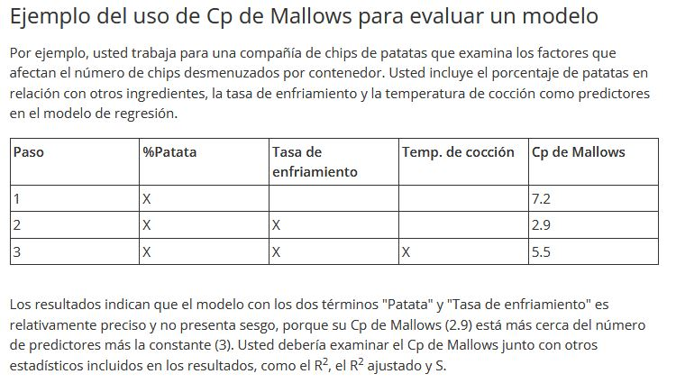

```r
knitr::include_graphics("FOTO3.JPG")
```

```r
#Figura 1: Ejemplo del uso del Estadístico de Mallows para evaluar un modelo
#Fuente: https://support.minitab.com/es-mx/minitab/18/help-and-how-to/modeling-statistics/regression/supporting-topics/goodness-of-fit-statistics/what-is-mallows-cp/
```

Así, para el ejemplo aquí utilizado (que responde a la base de datos antes especificada) puede obtenerse el estadístico $C_p$ de Mallows para todos los modelos posibles con las 7 variables disponibles. Para ello puede usarse la función `leaps`; nótese que no es necesario indicarle a R que obtenga el estadístico de Mallows mediante la sintaxis `method=Cp` puesto que este método es el establecido por defecto en la programación de R, por lo que en el escenario en que no se indique un “method” en específico el programa utilizará por defecto el criterio del estadístico de Mallows.

```r
sel = leaps(X,esper)
names(sel)
```

```
## [1] "which" "label" "size"  "Cp"
```

```r
sel$Cp
```

```
##  [1]  16.126760  58.058325  59.225241  94.755684 102.252357 111.351299
##  [7] 112.447938   9.669894  10.886508  12.475673  13.791499  17.280014
## [13]  17.634184  44.940876  49.351549  54.896851  58.701223   3.739878
## [19]   5.647595   8.727618   9.236254   9.903176  10.873258  11.169557
## [25]  11.190554  11.485646  11.705240   2.019659   5.411184   5.430093
## [31]   5.693495   5.780351   7.482910   7.484304   8.309352   8.884194
## [37]   9.015565   4.008737   4.012588   4.018235   7.174687   7.306932
## [43]   7.344256   7.428952   7.695471   8.888310   9.375028   6.001959
## [49]   6.007958   6.008526   9.149820   9.329008  10.401108  47.718647
## [55]   8.000000
```

Complementariamente, puede construirse una nueva matriz **mat** que en lugar de los criterios `sel$which` y `sel$adjr2` siga los criterios `sel$which`, `sel$Cp` y `sel$size`, agregando al igual que antes un contador para identificar cada modelo. Esto implicará la sobreeescritura de la matriz **mat**. Pueden seleccionarse con antelación únicamente las filas de **mat** que se corresponden con los modelos seleccionados en el punto anterior y comparar la columna del $C_p$ con la columna $size$ que corresponde al número de coeficientes (p). En cada caso puede determinarse si el modelo es sesgado o no, sin perder de vista que un modelo es sesgado según el estadístico de Mallows si $C_p>p$. De lo anterior se desprende que se está buscando un conjunto de modelos insesgados para los cuales se verifica la condición $C_p<p$ antes mencionada.

```r
mat=data.frame(cbind(1:k,sel$which,round(sel$Cp,2),sel$size))
colnames(mat)[9]<-"CP"
colnames(mat)[10]<-"p"
mat[c(28,38,39,40),]
```

```
##      V1 X1 X2 X3 X4 X5 X6 X7   CP p
## X4   28  1  0  0  1  1  1  0 2.02 5
## X5   38  1  1  0  1  1  1  0 4.01 6
## X5.1 39  1  0  1  1  1  1  0 4.01 6
## X5.2 40  1  0  0  1  1  1  1 4.02 6
```

### 4. Suma de Cuadrados Residuales de Predicción (PRESS)

1. Crea un modelo solamente con la variable **ingre**.
2. Toma el Estado i-ésimo y crea otro modelo basado en los demás Estados (excepto el i-ésimo).
3. Grafica las dos líneas de regresión y marca la observación del Estado i-ésimo en rojo para que se observe como se diferencian las dos líneas a la altura del ingreso de ese Estado.
4. Estima el promedio de la esperanza de vida para el i-ésimo Estado usando las dos ecuaciones.

```r
plot.press=function(i){
  mod =lm(esper~ingre,base)
  mod1=lm(esper ~ ingre,base[-i,])

  plot(base$ingre,base$esper,pch=18,xlab="ingreso",ylab="esperanza")
  points(base$ingre[i],base$esper[i],pch=18,col=2)
  abline(mod)
  abline(mod1,lty=2,col=2)
  abline(v=base$ingre[i],col=4,lty=2)
  legend(3000,max(esper),c("completo",paste("falta el ",i,sep="")),col=c(1,2),lty=c(1,2),bty="n")

  yi=predict(mod,data.frame(ingre=base$ingre[i]))
  yii=predict(mod1,data.frame(ingre=base$ingre[i]))
  res=c(yi,yii)
  names(res)=c("y_i","y_i(i)")
  return(round(res,2))
}
```

Así, puede usarse la función `plot.press` con diferentes estados, por ejemplo, con Alaska (i=2) o algún otro.

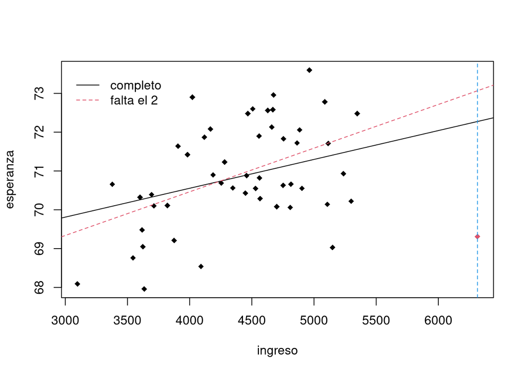

```
##    y_i y_i(i)
##  72.28  73.07
```

```r
plot.press(2)
```

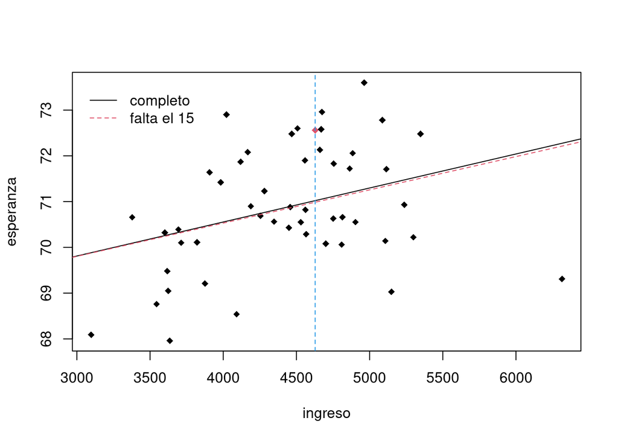

```
##    y_i y_i(i)
##  71.02  70.99
```

```r
plot.press(15)
```

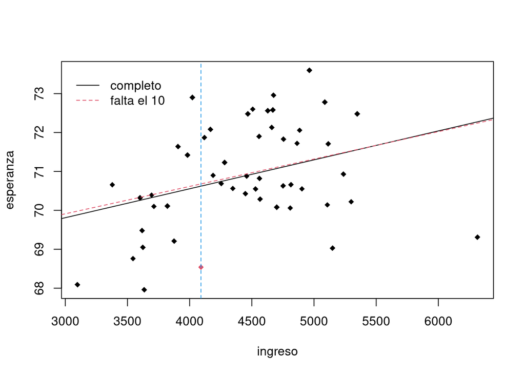

```
##    y_i y_i(i)
##  70.62  70.68
```

```r
plot.press(10)
```

#### 4.2. Aproximación Inferencial vía Residuos Estandarizados

Como señala https://www.statisticshowto.com/what-is-a-standardized-residuals/, los residuos estandarizados permiten normalizar el conjunto de datos de estudio en el contexto del análisis de regresión y de la ejecución de pruebas de hipótesis chi-cuadrado $χ^2$. Un residuo estandarizado es una razón: la diferencia entre el valor observado y el valor esperado (condicional, a posteriori) sobre la desviación estándar del valor esperado en la prueba de chi-cuadrado.

Como se señala en https://online.stat.psu.edu/stat501/lesson/11/11.4, existen varias medidas para identificar valores extremos de X (observaciones de alto $leverage$ o $influencia$) y valores de Y inusuales (valores atípicos). Al intentar identificar valores atípicos, un problema que puede surgir es cuando existe un valor atípico potencial que influye en el modelo de regresión hasta tal punto que la función de regresión estimada se “arrastrada” hacia el valor atípico potencial, de modo que no se marca como un valor atípico utilizando el criterio usual de residuos estandarizados. Para abordar este problema, los residuos eliminados ofrecen un criterio alternativo para identificar valores atípicos. La idea básica de esto es eliminar las observaciones una a la vez, reajustando cada vez el modelo de regresión en las n – 1 observaciones restantes. Luego, se comparan los valores de respuesta observados con sus valores ajustados basados en los modelos con la i-ésima observación eliminada. Esto produce residuos eliminados (no estandarizados). La estandarización de los residuos eliminados produce residuos eliminados studentizados, como se verá teóricamente a continuación.

Formalmente, es un resultado conocido del álgebra lineal que $y=Xβ+ε$, en donde $X_{n×p}$, $\hat{β}=(X'X)^{-1}X-y$ y $\hat{y}=X\hat{β}=X(X'X)^{-1}X'y=Hy$, donde $H=X(X'X)^{-1}X'$ es la matriz conocida como *matriz sombrero*. Los residuos son $e=y-\hat{y}=y-Hy=(I-H)y$. Adicionalmente, se sabe que la varianza poblacional $σ^2$ es desconocida y puede estimarse mediante la suma de cuadrados medios del error $MSE$. Así, los residuos pueden ser expresados mediante la ecuación $e_i^*=\frac{e_i}{\sqrt{MSE}}$ y se conocen como *residuos semistudentizados*. Puesto que la varianza de los residuos depende tanto de $σ^2$ como de $X$, la varianza estimada es $\hat{V}(e_i)=MSE(1-h_{ii})$, donde $h_{ii}$ es el $i$-ésimo elemento de la diagonal principal de la matriz sombrero. Así, los residuos estandarizados, también conocidos como *residuos internamente studentizados*, tienen la forma $r_i=\frac{e_i}{\sqrt{MSE(1-h_{ii})}}$. Sin embargo, se sabe que es imposible que un residuo individual y el MSE (que es la varianza del conjunto de residuos) no estén correlacionados (existe dependencia lineal) y, por consiguiente, es imposible que $r_i$ siga una distribución t de Student. Lo anterior representa un impedimento para realizar pruebas de significancia estadística de los coeficientes de regresión, puesto que la distribución t es junto con la F los dos tipos de distribución más utilizados (y no sólo en el contexto de regresión) para realizar pruebas de hipótesis, dentro de las cuales las pruebas de significancia de coeficientes son un tipo de ellas. La solución a la problemática antes descrita consiste en eliminar la $i$-ésima observación, ajustar la función de regresión a las $n-1$ observaciones restantes y luego obtener nuevas $\hat{y}$’s que pueden ser denotadas como $\hat{y}_{i(i)}$. La diferencia $d_i=y_i-\hat{y}_{i(i)}$ es llamada *residuo eliminado*. Una expresión equivalente que no requiere recomputación es: $d_i=\frac{e_i}{1-h_{ii}}$. Los residuos eliminados expresados de la forma anterior son la base para encontrar los residuos conocidos como *residuos eliminados studentizados* o *resiudos studentizados externamente*, los cuales adoptan la forma $t_i=\frac{d_i}{\sqrt{{\frac{MSE}{1-h_{ii}}}}}\sim{\sf t_{n-p-1}}$ o $t_i=\frac{e_i}{\sqrt{{{MSE(1-h_{ii})}}}}\sim{\sf t_{n-p-1}}$; véase https://stats.stackexchange.com/questions/99717/whats-the-difference-between-standardization-and-studentization/99723.

En lo que a la estimación de los diferentes tipos de residuos se refiere, debe comenzarse por obtener las **influencias** o **leverage** del modelo usando `hatvalues(mod)`; debe recordarse que las influencias son utilizadas para determinar que tanto impacto tiene una observación sobre los resultados de la regresión. Precisamente el análisis descriptivo anterior, en el que en una de las rectas de regresión (de las dos que aparecen en cada una de las cincuenta gráficas posibles) se omitía un Estado, tenía como finalidad verificar cuánto impactaba su ausencia (la del Estado sustraido) en la estimación realizada sobre la media condicional de $Y$. Al utilizar la sintaxis “mod=lm(esper~ingre,base)” se está planteando un modelo con la totalidad de Estados, del cual se calculan sus valores sombrero mediante la sintaxis `h = hatvalues(mod)`, sus residuos mediante `r=mod$res`, se estima el residuo de un modelo en el que no se considera el Estado i-ésimo en el análisis (en este caso Alaska) mediante `pred.r = r[2]/(1-h[2])` y, finalmente, la validez estadística de la estimación `pred.r = r[2]/(1-h[2])` se determina contrastándola con respecto al resultado de restarle a la media estimada $\hat{Y}_2$ (porque en este caso para Alaska, que ocupa la fila dos en la base de datos, que es una base de datos de corte transversal) la media estimada $\hat{Y}$ del modelo que no considera al i-ésimo Estado (aquí es Alaska).

```r
mod=lm(esper~ingre,base)
h = hatvalues(mod)
r=mod$res
pred.r = r[2]/(1-h[2])
round(pred.r,2)
```

```
## Alaska
##  -3.76
```

```r
esper[2]-73.07
```

```
## [1] -3.76
```

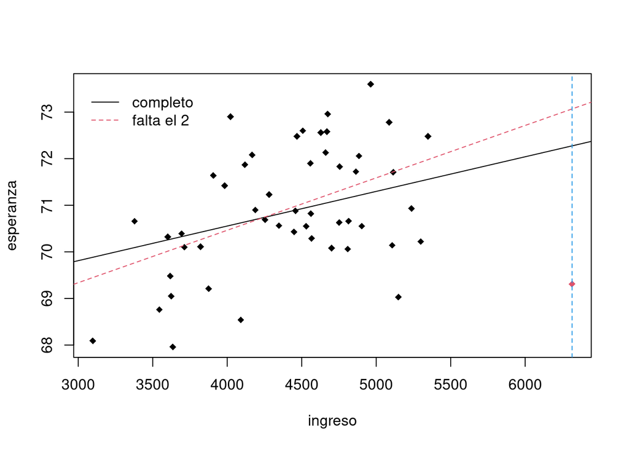

```
##    y_i y_i(i)
##  72.28  73.07
```

```r
plot.press(2)
```

Finalmente, puede obtenerse la Suma de Cuadrados Residuales de Predicción $PRESS$ utilizando los residuos eliminados globales (no únicamente para el Estado de Alaska) mediante la siguiente ecuación:
$$PRESS=\sum{( \frac{r_i}{1-h_i}} )^2$$
.

```r
d=r/(1-h)
press=t(d)%*%d
round(press,2)
```

```
##       [,1]
## [1,] 89.32
```

### 5. Comparación de Modelos vía $PRESS$

Es posible comparar el modelo que únicamente contempla la variable ingreso **ingre** con el que se obtiene en un modelo que contenga en su lugar la cantidad de población del Estado **pop** y su tasa de criminalidad **crim**. Esto con el fin de verificar cuál de los dos modelos es más sensible a valores extremos de X al realizar estimaciones de la media condicional $\hat{Y}$ de la variable *esperanza de vida*.

```r
mod=lm(esper~ingre,base)
r=mod$res
h=hatvalues(mod)
d=r/(1-h)
press=t(d)%*%d
round(press,2)
```

```
##       [,1]
## [1,] 89.32
```

```r
mod2= lm(esper~pop+crim,base)
r=mod2$res
h=hatvalues(mod2)
d=r/(1-h)
press=t(d)%*%d
round(press,2)
```

```
##       [,1]
## [1,] 34.07
```

Se observa que el modelo `mod` es más sensible, puesto que su PRESS es más alto (89.32).

Debe decirse que la matriz “d” es conocida también como *matriz de Gramm*, por lo que su determinante es igual al producto de sí y su transpuesta, es decir, `t(d)%*%d`. Como se verifica en https://www.wikiwand.com/en/Gram_matrix, la matriz de Gramm cuyos elementos pertenecen a los reales tiene la característica de ser simétrica (matriz cuadrada que es igual a su transpuesta); la matriz de Gramm de cualquier base ortonormal (conjunto de vectores linealmente independientes que generan un espacio lineal -conocido como *span lineal*- denso dentro del espacio de referencia) es una matriz identidad.

El modelo anterior puede expandirse en predictores considerando ahora población **pop**, nivel de ingreso **ingre**, porcentaje de población analfebeta **analf** y la extensión en millas cuadradas **area** para explicar la esperanza de vida (medida en años).

```r
mod0= lm(esper~pop+ingre+analf+area,base)
r=mod0$res
h=hatvalues(mod0)
d=r/(1-h)
press=t(d)%*%d
round(press,2)
```

```
##       [,1]
## [1,] 91.43
```

El modelo `mod0` es aún más sensible a los datos provistos por el Estado de Alaska que el modelo `mod`

Así como se amplió la cantidad de variables en consideración al pasar del modelo `mod` al modelo `mod0`, también podría realizarse el procedimiento anterior para un modelo que considere la totalidad de las variables disponibles. Una forma para evitar escribir todas las variable en es usar un punto después de **~**, además de indicar de cuál base provienen los datos. De esta forma R entiende que debe considerar todas las variables de esa base como predictores, con excepción de la variable que se indica como respuesta.

```r
mod_comp= lm(esper~., base)
r=mod_comp$res
h=hatvalues(mod_comp)
d=r/(1-h)
press=t(d)%*%d
round(press,2)
```

```
##       [,1]
## [1,] 41.32
```

Como se verifica de las pruebas antes realizadas, el modelo completo `mod_comp` tiene una $PRESS$ menor (más bajo) que el modelo que utiliza 4 predictores (*i.e.*, `mod0`) para explicar la media condicional de la esperanza de vida, lo que indica menor *leverage* en relación al Estado de Alaska.

### 6. Construcción Escalonada de Modelos de Predicción

#### 6.1. Aspectos Teóricos Generales

Como se conoce de los cursos de álgebra lineal, el mecanismo de *eliminación gaussiana* o *reducción de por filas*, es un proceso secuencial de *operaciones elementales entre filas* realizadas sobre la correspondiente matriz de coeficientes con la finalidad de estimar el rango de la matriz, el determinante de una matriz cuadrada y la inversa de una matriz invertible, en cuanto este mecanismo prepara las condiciones para resolver el sistema de ecuaciones; sobre los orígenes históricos de este mecanismo debe decirse que, como se señala en https://en.wikipedia.org/wiki/Gaussian_elimination, casos particulares de este método se conocían descubiertos por matemáticos chinos (sin prueba formal) en el año 179 de la era común C.E. (que es una forma no-cristiana de expresar la era que inicia en el año en que se supone nació Jesucristo).

Los mecanismos matemáticos anteriores, utilizados en el procedimiento estadístico de selección de los predictores de la media condicional de alguna variable de respuesta, se conocen como *regresión escalonada*. Como se señala en https://en.wikipedia.org/wiki/Stepwise_regression, la regresión escalonada es un método de ajuste de modelos de regresión en el que la elección de las variables predictivas se realiza mediante un procedimiento automático (…) En cada paso, se considera una variable para sumar o restar del conjunto de variables explicativas basado en algún criterio preespecificado. Por lo general, esto toma la forma de una secuencia hacia adelante, hacia atrás o combinada de pruebas F o pruebas t. La práctica frecuente de ajustar el modelo final seleccionado seguido de reportar estimaciones e intervalos de confianza sin ajustarlos para tener en cuenta el proceso de construcción del modelo ha llevado a llamadas a dejar de usar la construcción escalonada de modelos por completo (…) o al menos asegurarse de que en el modelo la incertidumbre se refleja correctamente (…) Las alternativas incluyen otras técnicas de selección de modelos, como $R^2$ ajustado, ek criterio de información de Akaike, el criterio de información bayesiano, el $C_p$ de Mallows, la $PRESS$ o la *tasa de falso descubrimiento*.

La construcción escalonada de un modelo puede suscitarse fundamentalmente de tres maneras:

1.*Selección hacia adelante*, que implica comenzar sin variables en el modelo, comprobar lo que ocurre al adicionar cada variable utilizando un criterio de ajuste del modelo elegido, agregando la variable (si la hubiese) cuya inclusión permita la mejora estadísticamente más significativa del ajuste y repetir este proceso hasta ningún predictor mejore el modelo de manera estadísticamente significativa. Véase https://www.analyticsvidhya.com/blog/2021/04/forward-feature-selection-and-its-implementation/

2. *Eliminación hacia atrás*, que implica comenzar con todas las variables candidatas, probar la eliminación de cada variable utilizando un criterio de ajuste del modelo elegido, eliminar la variable (si la hubiese) cuya pérdida produce el deterioro más insignificante estadísticamente del ajuste del modelo, y repetir este proceso hasta que no se pueden eliminar más variables sin una pérdida de ajuste estadísticamente insignificante. Véase https://www.analyticsvidhya.com/blog/2021/04/backward-feature-elimination-and-its-implementation/?utm_source=blog&utm_medium=Forward_Feature_Elimination.
3. *Eliminación bidireccional*, una combinación de 1 y 2, probando en cada paso las variables que se incluirán o excluirán.

#### 6.2. Método de Eliminación Hacia Atrás en R

##### 6.2.1. Eliminación Hacia Atrás con Probabilidad F

Para eliminar variables secuencialmente se usa la función `drop1`, que proporciona el estadístico F correspondiente a la eliminación de una única variable explicativa; el estadístico F arrojado por esta sintaxis debe interpretarse como la probabilidad de materialización de la probabilidad de rechazar $H_0:β_1=B_2=⋯=B_i=0$ siendo esta verdadera. A causa de lo anterior, un valor F alto indica que la probabilidad de la materialización antes descrita es alta y, ante semejante riesgo, la decisión racional es fallar en rechazar $H_0$ sobre la significancia estadística nula global de los coeficientes de regresión. Fallar en rechazar $H_0$ implica que probabilísticamente hablando no existen consecuencias relevantes (a nivel de capacidad predictiva) si se elimina el modelo en cuestión, por lo que un F mayor que el nivel de significancia $α$ preestablecido (que es la probabilidad de cometer error tipo I, fijada por el investigador con base a la información histórica y a criterios de experto experimentado) significa que ese coeficiente de regresión no es estadísticamente relevante y puede eliminarse.

Puede escribirse el modelo completo (con los 7 predictores) y luego utilizar `drop1(mod,test="F")` para verificar cuál es la primera variable que se recomienda eliminar tras el proceso antes descrito. Como se adelantó, se deben eliminar aquellos predictores cuyo valor de probabilidad F sea más alto.

```r
mod3=lm(esper~., base)
moda=mod3
drop1(moda,test="F")
```

```
## Single term deletions
##
## Model:
## esper ~ pop + ingre + analf + crim + grad + temp + area
##        Df Sum of Sq    RSS     AIC F value   Pr(>F)
## <none>              23.297 -22.185
## pop     1    1.7472 25.044 -20.569  3.1498  0.08318 .
## ingre   1    0.0044 23.302 -24.175  0.0080  0.92934
## analf   1    0.0047 23.302 -24.174  0.0085  0.92687
## crim    1   23.1411 46.438  10.305 41.7186 8.68e-08 ***
## grad    1    2.4413 25.738 -19.202  4.4011  0.04197 *
## temp    1    1.8466 25.144 -20.371  3.3290  0.07519 .
## area    1    0.0011 23.298 -24.182  0.0020  0.96491
## ---
## Signif. codes:  0 '***' 0.001 '**' 0.01 '*' 0.05 '.' 0.1 ' ' 1
```

Si se comparan los resultados de la sintaxis `drop1` con los de `summary`, se puede verificar que las probabilidades F y t coinciden. Esto sucede en este ejemplo porque no hay variables categóricas con más de 2 categorías; sin embargo, cuando se cuenta con variables categóricas con más de 2 categorías, no se debe usar `summary` porque en tal caso las probabilidades F y t no son equivalentes.

```r
summary(moda)
```

```
##
## Call:
## lm(formula = esper ~ ., data = base)
##
## Residuals:
##      Min       1Q   Median       3Q      Max
## -1.48895 -0.51232 -0.02747  0.57002  1.49447
##
## Coefficients:
##               Estimate Std. Error t value Pr(>|t|)
## (Intercept)  7.094e+01  1.748e+00  40.586  < 2e-16 ***
## pop          5.180e-05  2.919e-05   1.775   0.0832 .
## ingre       -2.180e-05  2.444e-04  -0.089   0.9293
## analf        3.382e-02  3.663e-01   0.092   0.9269
## crim        -3.011e-01  4.662e-02  -6.459 8.68e-08 ***
## grad         4.893e-02  2.332e-02   2.098   0.0420 *
## temp        -5.735e-03  3.143e-03  -1.825   0.0752 .
## area        -7.383e-08  1.668e-06  -0.044   0.9649
## ---
## Signif. codes:  0 '***' 0.001 '**' 0.01 '*' 0.05 '.' 0.1 ' ' 1
##
## Residual standard error: 0.7448 on 42 degrees of freedom
## Multiple R-squared:  0.7362, Adjusted R-squared:  0.6922
## F-statistic: 16.74 on 7 and 42 DF,  p-value: 2.534e-10
```

De los resultados anteriores se desprende que el primer predictor a ser eliminado es la variable **area**, pues tiene la probabilidad F más alta. Para materializar la eliminación se puede actualizar el modelo anterior mediante `moda=update(moda,.~.-area)`.

```r
moda=update(moda,.~.-area)
drop1(moda,test="F")
```

```
## Single term deletions
##
## Model:
## esper ~ pop + ingre + analf + crim + grad + temp
##        Df Sum of Sq    RSS     AIC F value    Pr(>F)
## <none>              23.298 -24.182
## pop     1    1.7599 25.058 -22.541  3.2481   0.07852 .
## ingre   1    0.0059 23.304 -26.170  0.0109   0.91740
## analf   1    0.0038 23.302 -26.174  0.0069   0.93400
## crim    1   26.2721 49.570  11.569 48.4887 1.454e-08 ***
## grad    1    2.9804 26.279 -20.163  5.5007   0.02369 *
## temp    1    2.0488 25.347 -21.968  3.7813   0.05839 .
## ---
## Signif. codes:  0 '***' 0.001 '**' 0.01 '*' 0.05 '.' 0.1 ' ' 1
```

Y así puede continuarse hasta que, por ejemplo, todas las probabilidades sean menores a 0.15 (o a algún valor$α$ preestablecido de la forma antes descrita).

```r
moda=update(moda,.~.-analf)
drop1(moda,test="F")
```

```
## Single term deletions
##
## Model:
## esper ~ pop + ingre + crim + grad + temp
##        Df Sum of Sq    RSS     AIC F value    Pr(>F)
## <none>              23.302 -26.174
## pop     1     1.887 25.189 -24.280  3.5637   0.06566 .
## ingre   1     0.006 23.308 -28.161  0.0114   0.91531
## crim    1    34.739 58.041  17.456 65.5964 2.907e-10 ***
## grad    1     3.495 26.797 -21.187  6.5993   0.01367 *
## temp    1     3.037 26.339 -22.048  5.7351   0.02095 *
## ---
## Signif. codes:  0 '***' 0.001 '**' 0.01 '*' 0.05 '.' 0.1 ' ' 1
```

```r
moda=update(moda,.~.-ingre)
drop1(moda,test="F")
```

```
## Single term deletions
##
## Model:
## esper ~ pop + crim + grad + temp
##        Df Sum of Sq    RSS     AIC F value    Pr(>F)
## <none>              23.308 -28.161
## pop     1     2.064 25.372 -25.920  3.9841  0.052005 .
## crim    1    34.816 58.124  15.528 67.2182 1.775e-10 ***
## grad    1     5.112 28.420 -20.246  9.8703  0.002968 **
## temp    1     3.122 26.430 -23.877  6.0271  0.018018 *
## ---
## Signif. codes:  0 '***' 0.001 '**' 0.01 '*' 0.05 '.' 0.1 ' ' 1
```

Finalmente, se obtiene que el modelo sugerido contempla las variables **pop**, **crim**, **grad** y **temp**.

##### 6.2.2. Eliminación Hacia Atrás con AIC

Adicionalmente, en lugar de usar el criterio de la probabilidad F se pueden usar criterios de información. Para usar el criterio de Akaike (AIC) simplemente no se indica nada en `test`, pues el AIC es el criterio por defecto que utiliza `drop1`. En este caso, la columna de AIC indica el valor del AIC que se obtendría si se elimina esa variable. Puesto que el objetivo es aumentar el AIC (porque eso haría al predictor candidato de ser eliminado), entonces se elimina la variable que más disminuye el AIC, generando luego un nuevo modelo (con las variables que menos disminuyen el AIC) que se compara con el modelo anterior, y así sucesivamente, hasta que la eliminación de cualquier variable aumenta el AIC con respecto al modelo anterior en lugar de disminuirlo, puesto que esta es la señal que en términos de robustez estadística del modelo no es recomendable eliminar más predictores.

```r
moda=mod3
drop1(moda)
```

```
## Single term deletions
##
## Model:
## esper ~ pop + ingre + analf + crim + grad + temp + area
##        Df Sum of Sq    RSS     AIC
## <none>              23.297 -22.185
## pop     1    1.7472 25.044 -20.569
## ingre   1    0.0044 23.302 -24.175
## analf   1    0.0047 23.302 -24.174
## crim    1   23.1411 46.438  10.305
## grad    1    2.4413 25.738 -19.202
## temp    1    1.8466 25.144 -20.371
## area    1    0.0011 23.298 -24.182
```

```r
moda=update(moda,.~.-area)
drop1(moda)
```

```
## Single term deletions
##
## Model:
## esper ~ pop + ingre + analf + crim + grad + temp
##        Df Sum of Sq    RSS     AIC
## <none>              23.298 -24.182
## pop     1    1.7599 25.058 -22.541
## ingre   1    0.0059 23.304 -26.170
## analf   1    0.0038 23.302 -26.174
## crim    1   26.2721 49.570  11.569
## grad    1    2.9804 26.279 -20.163
## temp    1    2.0488 25.347 -21.968
```

```r
moda=update(moda,.~.-analf)
drop1(moda)
```

```
## Single term deletions
##
## Model:
## esper ~ pop + ingre + crim + grad + temp
##        Df Sum of Sq    RSS     AIC
## <none>              23.302 -26.174
## pop     1     1.887 25.189 -24.280
## ingre   1     0.006 23.308 -28.161
## crim    1    34.739 58.041  17.456
## grad    1     3.495 26.797 -21.187
## temp    1     3.037 26.339 -22.048
```

```r
moda=update(moda,.~.-ingre)
drop1(moda)
```

```
## Single term deletions
##
## Model:
## esper ~ pop + crim + grad + temp
##        Df Sum of Sq    RSS     AIC
## <none>              23.308 -28.161
## pop     1     2.064 25.372 -25.920
## crim    1    34.816 58.124  15.528
## grad    1     5.112 28.420 -20.246
## temp    1     3.122 26.430 -23.877
```

El procedimiento antes descrito se puede realizar de forma automática con la sintaxis `step` mediante`step(mod)`. Tras ello, puede almacenarse el resultado en una estructura de datos (aquí llamada “mod4”#“) y aplicar `summary` sobre dicho objeto.

```r
mod4=step(mod3)
```

```
## Start:  AIC=-22.18
## esper ~ pop + ingre + analf + crim + grad + temp + area
##
##         Df Sum of Sq    RSS     AIC
## - area   1    0.0011 23.298 -24.182
## - ingre  1    0.0044 23.302 -24.175
## - analf  1    0.0047 23.302 -24.174
## <none>               23.297 -22.185
## - pop    1    1.7472 25.044 -20.569
## - temp   1    1.8466 25.144 -20.371
## - grad   1    2.4413 25.738 -19.202
## - crim   1   23.1411 46.438  10.305
##
## Step:  AIC=-24.18
## esper ~ pop + ingre + analf + crim + grad + temp
##
##         Df Sum of Sq    RSS     AIC
## - analf  1    0.0038 23.302 -26.174
## - ingre  1    0.0059 23.304 -26.170
## <none>               23.298 -24.182
## - pop    1    1.7599 25.058 -22.541
## - temp   1    2.0488 25.347 -21.968
## - grad   1    2.9804 26.279 -20.163
## - crim   1   26.2721 49.570  11.569
##
## Step:  AIC=-26.17
## esper ~ pop + ingre + crim + grad + temp
##
##         Df Sum of Sq    RSS     AIC
## - ingre  1     0.006 23.308 -28.161
## <none>               23.302 -26.174
## - pop    1     1.887 25.189 -24.280
## - temp   1     3.037 26.339 -22.048
## - grad   1     3.495 26.797 -21.187
## - crim   1    34.739 58.041  17.456
##
## Step:  AIC=-28.16
## esper ~ pop + crim + grad + temp
##
##        Df Sum of Sq    RSS     AIC
## <none>              23.308 -28.161
## - pop   1     2.064 25.372 -25.920
## - temp  1     3.122 26.430 -23.877
## - grad  1     5.112 28.420 -20.246
## - crim  1    34.816 58.124  15.528
```

```r
summary(mod4)
```

```
##
## Call:
## lm(formula = esper ~ pop + crim + grad + temp, data = base)
##
## Residuals:
##      Min       1Q   Median       3Q      Max
## -1.47095 -0.53464 -0.03701  0.57621  1.50683
##
## Coefficients:
##               Estimate Std. Error t value Pr(>|t|)
## (Intercept)  7.103e+01  9.529e-01  74.542  < 2e-16 ***
## pop          5.014e-05  2.512e-05   1.996  0.05201 .
## crim        -3.001e-01  3.661e-02  -8.199 1.77e-10 ***
## grad         4.658e-02  1.483e-02   3.142  0.00297 **
## temp        -5.943e-03  2.421e-03  -2.455  0.01802 *
## ---
## Signif. codes:  0 '***' 0.001 '**' 0.01 '*' 0.05 '.' 0.1 ' ' 1
##
## Residual standard error: 0.7197 on 45 degrees of freedom
## Multiple R-squared:  0.736,  Adjusted R-squared:  0.7126
## F-statistic: 31.37 on 4 and 45 DF,  p-value: 1.696e-12
```

##### 6.2.2. Eliminación Hacia Atrás con BIC

###### 6.2.2.1. Aspectos Teóricos Relevantes del BIC

Si en lugar del criterio AIC se desease utilizar el criterio bayesiano de información (BIC) se debe indicar en la sintaxis `step` mediante `k=log(n)`. Debe agregarse que, como se señala en (Bishop, Christopher M. Pattern Recognition and Machine Learning. 2006, p. 217), el criterio bayesiano de información penaliza la complejidad del modelo y es el criterio expuesto por Bishop en el lugar referido el que muestra la penalización que el BIC ejerce sobre la complejidad del modelo y que se conoce como *factor de Occam*.

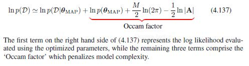

```r
knitr::include_graphics("FOTO4.JPG")
```

```r
#Figura 2: Evaluación de la log-verosimilitud empleando parámetros optimizados
#Fuente: Bishop, Christopher M. Pattern Recognition and Machine Learning. 2006, p. 216-17.
```

Debe decirse sobre el factor de Occam que, como puede verificarse en [David J. Spiegelhalter, Nicola G. Best, Bradley P. Carlin & Angelika Van Der Linde. Bayesian measures of model complexity and fit. Journal of Royal Statistical Society, Series B (Statistical Methodology); https://rss.onlinelibrary.wiley.com/doi/pdf/10.1111/1467-9868.00353] y en (van der Linde, Angelika. A Bayesian view of model complexity. Statistica Neerlandica xx, year xx-xx, special issue: All Models Are Wrong…; https://statmodeling.stat.columbia.edu/wp-content/uploads/2013/08/snavdlmc.pdf), no existe una definición analítica para el mismo, *i.e.*, una definición que pueda ser sustentada lógicamente desde algún marco teórico en congruencia clara y directa con un marco matemático autodemostrable dentro de teoría de conjuntos ZF-C (Zermelo-Fraenkel con Axioma de Elección) que la modele.

En este sentido, la investigación de Spiegelhalter et al es una de las investigaciones más importantes de al menos las últimas dos décadas a nivel de la teoría de las probabilidades y su importancia es aún mayor si el marco de referencia es únicamente la teoría bayesiana de probabilidades. En síntesis, los autores y autora de la investigación concluyen que la medida de complejidad bayesiana (que es la estructura matemática que aparece en la obra citada de Christopher Bishop) tiene como trasfondo común con el criterio DIC (que es la versión generalizada del AIC, de naturaleza teórica frecuentista, que tiene su propia penalización de la complejidad del modelo y por consiguiente su propia medición de dicha complejidad) la teoría de la información (rama de la teoría de las probabilidades que versa sobre las estructuras matemáticas que rigen la transmisión y el procesamiento de la información y se ocupa de la medición de la información y de la representación de la misma, así como también de la capacidad de los sistemas de comunicación para transmitir y procesar información; véase https://es.wikipedia.org/wiki/Teor%C3%ADa_de_la_informaci%C3%B3n), que el DIC y el BIC tienen una justificación lógica similar aunque el DIC tiene una campo de aplicación más amplio. Adicionalmente, se señala que la metodología de medición de complejidad bayesiana que ellos proponen es aplicable a toda la clase de modelos y que únicamente requiere de un trabajo analítico “despreciable” (p. 613) relativo a la configuración de un muestreo del tipo Monte Carlo basado en cadenas de Markov. Además, existe un problema señalado por los autores y autora relativo a que es difícil explicar si las diferencias entre los criterios de medición de complejidad del BIC y del DIC son realmente diferentes en términos estadísticos, puesto que es aún más difícil determinar el error del DIC en pruebas Monte Carlo (para ello se cita una investigación previa que señala esta dificultad). La publicación de este documento de investigación generó la apertura de un debate alrededor del mismo, que contó con la participación de S. Brooks (University of Cambridge), Jim Smith (University of Warwick), Aki Vehtari (Helsinki University of Technology), Martyn Plummer (International Agency of Research on Cancer, Lyon), Mervyn Stone (University College London), Christian P. Robert (Université Paris Dauphine) y D. M. Titterington (University of Glasgow), el mismísimo J. A. Nelder en persona (Impercial College of Science, Techonology and Medicine, London), Anthony Atkinson (London School of Economics and Political Science), A. P. David (University College London), José M. Bernardo (Universitat de València), Sujit K. Sahu (University of Southampton), Sylvia Richardson (Imperial College School of Medicine, London), Peter Green (University of Bristol), Kenneth P. Burnham (US Geological Survey and Colorado State University, Fort Collins), María Delorio (University of Oxford) y Christian P. Robert (Université Paris Dauphine), David Draper (University of California, Santa Cruz), Alan E. Gelfand (Duke University Durkham) y Matilde Travisani (University of Trieste), Jim Hodges (University of Minesota, Minneapolis), Youngjo Lee (Seoul National University), Xavier de Luna (Uméa University) y, finalmente, Xiao-Li Meng (Harvard University, University of Chicago); tremendo crossover, mucho mejor que *Crisis en Tierras Infinitas (1985-86)*… palabras mayores. Los posicionamientos de los autores y autoras participantes son diversas y profundas, sin embargo, se hará una recapitulación de aquellos que señalen debilidades la medición bayesiana de complejidad de un modelo estadístico.

Brooks (p. 616-18) plantea que la investigación (como casi toda buena investigación) deja preguntas abiertas, específicamente él señala que la ecuación 9 de la página 587 utiliza para calcular dicha complejidad el valor esperado, pero ¿por qué no la moda o la mediana?, ¿cuál es la justificación teórica de ello?, y de ello se deriva también ¿cómo se debe decidir entonces que el parámetro estimado debe ser la media, la moda o la mediana?, lo cual es relevante en cuanto podría conducir a diferencias importantes con el DIC; finalmente, ¿cómo se pueden ser comparables el análisis del modelo bajo el DIC con el análisis del modelo bajo las probabilidades posteriores (enfoque bayesiano) y por qué difieren?, ¿pueden ambas ser “correctas” de alguna manera significativa?

Por su parte, Jim Smith (p. 619-20) señala que no encontró errores técnicos (*i.e.*, matemáticos), pero que encontró cuatro problemas fundacionales. El primero que señala es que las implicaciones predictivas de todas las configuraciones del prior relativas a las variaciones en los ejemplos resueltos en la Sección 8 son increíbles (no en un sentido que podría considerarse positivo), puesto que según Smith no representan juicios de expertos cuidadosamente obtenidos, sino las opiniones de un usuario de software vacío. También señala que, al principio de la Sección 1, los autores afirman que quieren identificar modelos sucintos que parecen describir la información [¿acerca de valores de parámetros “verdaderos” incorrectos (ver Sección 2.2)?] en los datos con precisión, sin embargo, señala también que en un análisis bayesiano, la separación entre la información de los datos y el prior es artificial e inapropiada; señala que “Un análisis bayesiano en nombre de un experto en auditoría remota (Smith, 1996) podría requerir la selección de un prior que sea robusto dentro de una clase de creencias de diferentes expertos (por ejemplo, Pericchi y Walley (1991)). A veces, los prior predeterminados pueden justificarse para modelos simples. Incluso entonces, los modelos dentro de una clase de selección deben tener parametrizaciones compatibles: ver Moreno et al. (1998). Sin embargo, en los ejemplos en los que”el número de parámetros supera en número a las observaciones”, afirman que sus enfoques de enfoque, es poco probable los prior predeterminados (por defecto) muestren alguna robustez (estadística). En particular, fuera del dominio de la estimación local vaga o de la estimación de la varianza de separación (discutida en la Sección 4), aparentemente los antecedentes por defecto pueden tener una fuerte influencia en las implicaciones del modelo y, por lo tanto, en la selección.”, de lo cual se deriva una razonable insatisfacción ante la expresión la afirmación de los autores y autora sobre la baja probabilidad de que los prior muestren robustez.

Martyn Plummer (p. 621) señala lo que a su juicio son debilidades en la derivación heurística del DIC y de ello se deriva su señalamiento de sustento formal ;como señalan (Rosental & Iudin. Diccionario Filosófico. Editorial Tecolut, 1971. p. 215-216), en términos históricos la palabra “heurística” proviene del griego εὑρίσκω, que significa “discuto”. Es el arte de sostener una discusión y floreció sobre todo entre los sofistas de la antigua Grecia. Surgida como medio de buscar la verdad a través de la polémica, se escindió pronto en dialéctica y sofística. Sócrates, con su método, desarrolló la primera. En cambio, la sofística, tendiente sólo a alcanzar la victoria sobre el contrincante en la discusión, redujo la heurística a una suma de procedimientos que podían aplicarse con el mismo éxito tanto para demostrar una aseveración, cualquiera que fuese, como para refutarla. De ahí que ya Aristóteles no estableciera ninguna diferencia entre heurística y sofística. En la actualidad, al hablar de métodos heurísticos se hace referencia a una especie de atajos para las derivaciones rigurosas que implican mayor costo computacional, por lo que su carácter de verdad es siempre de corto plazo (provisional).

Mervyn Stone (p. 621) señala que la investigación de 2002 “bastante económico” en lo relativo a la *verdad fundamental* (véase https://marxianstatistics.files.wordpress.com/2020/12/sobre-los-estimadores-de-bayes-el-analisis-de-grupos-y-las-mixturas-gaussianas-isadore-nabi.pdf, p. 43-44), que si la sección 7.3 pudiera desarrollarse rigurosamente (puesto que le parece gnoseológicamente cuestionable el uso de $E_Y$), “(…) otra conexión (a través de la ecuación $(33)$) podría ser que $DIC ≈ −2A$. Pero, dado que la sección 7.3 invoca el supuesto de”buen modelo” y pequeños $|\hat{θ}-θ|$ para la expansión de la serie de Taylor (es decir, $n$ grande), tal conexión sería tan artificial como la de $A$ con el criterio de información de Akaike: ¿por qué no seguir con la forma prístina (hoy en día calculable) de $A$, que no necesita $n$ grande o verdad? , ¿y cuál acomoda la estimación de θ en el nivel de independencia de un modelo bayesiano jerárquico? Si la sensibilidad del logaritmo a probabilidades insignificantes es objetable, los bayesianos deberían estar felices de sustituirlo por una medida subjetivamente preferible de éxito predictivo.” Es imposible cuestionar a Stone en cuanto a que, dado el enseñoramiento que en la teoría bayesiana de probabilidades tiene la escuela bayesiana subjetiva, el promedio del gremio bayesiano estaría filosóficamente satisfecha con renunciar a elementos objetivos (en este caso son requerimientos preestablecidos por la teoría del aprendizaje estadístico que condicionan la validez gnoseológica del modelo propuesto como un todo, como una muestra grande y/o una verdad fundamental) si representan un punto de discordia y pueden ser sustituidos por algún criterio de decisión que pueda ser determinado; que en paz descanse su alma https://www.ucl.ac.uk/statistics/sites/statistics/files/meryvn-stone-obituary.pdf.

Christian P. Robert y D. M. Titterington (p. 621) señalan que la estructura matemática planteada por los autores de la investigación para determinar la complejidad de un modelo desde la perspectiva bayesiana parecería hacer un uso duplicado (repetido en dos ocasiones) del conjunto de datos, la primera vez lo hacen para determinar la distribución posterior y la segunda para calcular la verosimilitud observada (o verosimilitud a priori, sin considerar información adicional). Este uso duplicado del conjunto de datos puede conducir a un sobreajuste del modelo; señalan que este tipo específico de problemática surgió antes en la investigación de (Aitkin, 1991).

Seguramente el invitado más célebre entre todos los que asistieron a este maravilloso coloquio académico fue John Nelder, padre de los modelos lineales generalizados. Antes de exponer su planteamiento, deben introducirse algunas cuestiones. En primer lugar, el *escape de amoníaco* en aplicaciones industriales es a lo que los autores se refieren (y se refirará Nelder) como *stack loss* (p. 609). En segundo lugar, la tabla 2 a la que se referirá Nelder es la siguiente:

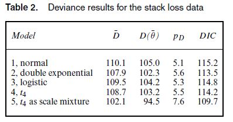

```r
knitr::include_graphics("TABLA2.JPG")
```

```r
#Figura 3: Tabla 2. Resultados de desviación para los datos de pérdida de amoníaco.
#Fuente: Spiegelhalter, Best, Carlin & van der Linde. Bayesian measures of model complexity and fit, p. 610.
```

Así, Nelder (p. 622) señala: “Mi colega, el profesor Lee, ha planteado algunos puntos generales que conectan el tema de este artículo con nuestro trabajo sobre modelos lineales generalizados jerárquicos basados en la probabilidad. Quiero plantear un punto específico y dos generales. (a) El profesor Dodge ha demostrado que, de las 21 observaciones en el conjunto de datos de pérdida de amoníaco, ¡solo cinco no han sido declaradas como valores atípicos por alguien! Sin embargo, existe un modelo simple en el que ninguna observación aparece como un valor atípico. Es un modelo lineal generalizado con distribución gamma, log-link y predictor lineal x2 + log.x1 / Å log.x3 /: Esto da las siguientes entradas para la Tabla 2 en el documento: 98.3 92.6 6.2 104.5 (estoy en deuda con el Dr. Best por calcularlos). Es claramente mejor que los modelos existentes usados en la Tabla 2. (b) Este ejemplo ilustra mi primer punto general. Creo que ha pasado el tiempo en que bastaba con asumir un vínculo de identidad para los modelos y permitir que la distribución solo cambiara. Deberíamos tomar como nuestro conjunto de modelos de línea base al menos la clase de modeloos lineales generalizados definida por distribución, enlace y predictor lineal, con la elección de escalas para las covariables en el caso del predictor lineal. (c) Mi segundo punto general es que, para mí, no hay suficiente verificación de modelos en el artículo (supongo que el uso de tales técnicas no va en contra de las reglas bayesianas). Por ejemplo, si un conjunto de efectos aleatorios es suficientemente grande en número y el modelo postula que están distribuidos normalmente, sus estimaciones deben graficarse para ver si se parecen a una muestra de tal distribución. Si parecen, por ejemplo, fuertemente bimodales, entonces el modelo debe revisarse.” Que en paz descanse su alma.

Anthony Atkinson (p. 622) señala que dirige su participación al contexto de la regresión, concluyendo que este criterio de selección de modelos (el BIC planteado por los autores, que es el estimado mediante la sintaxis de R) es un primer paso, que necesita ser complementado mediante pruebas de diagnóstico y gráficos. Para finalizar plantea que “Estos ejemplos muestran que la búsqueda hacia adelante es una herramienta extremadamente poderosa para este propósito. También requiere muchos ajustes del modelo a subconjuntos de datos. ¿Puede combinarse con los apreciables cálculos de los métodos de Monte Carlo de la cadena de Markov de los autores?” Que en paz descanse su alma.

A.P. Dawid plantea que el artículo debería haberse titulado “Medidas de la complejidad y el ajuste del modelo bayesiano”, ya que según él son los modelos, no las medidas, los que son bayesianos. Una vez que se han especificado los ingredientes de un problema, cualquier pregunta relevante tiene una respuesta bayesiana única. La metodología bayesiana debe centrarse en cuestiones de especificación o en formas de calcular o aproximar la respuesta. No se requiere nada más (…) Un lugar donde un bayesiano podría querer una medida de la complejidad del modelo es como un sustituto de p en la aproximación del criterio de información de Bayes a la probabilidad marginal, por ejemplo, para modelos jerárquicos. Pero en tales casos, la definición del tamaño de muestra $n$ puede ser tan problemática como la de la dimensión del modelo $p$. Lo que necesitamos es un mejor sustituto del término completo $p⋅log(n)$“. En línea con la gnoseología marxiana, lo adecuado parecería ser considerar que tanto los modelos como las medidas son bayesianos (o de otra escuela de filosofía de las probabilidades).

Las participaciones restantes son no tanto relativas a cuestiones metodológicas como a cuestiones filosóficas-fundacionales de la teoría bayesiana de las probabilidades y de la teoría de las probabilidades en general (puesto que el DIC, que es un criterio de información presentado por los mismos autores que presentan el BIC, no es bayesiano debido a que es una generalización del AIC -que es frecuentista-); de hecho, la transición de cuestiones metodológicas a filosóficas-fundacionales se expresa en el planteamiento de Dawid, quien aunque aborda cuestiones metodológicas lo hace con base en la lógica filosófica de que los modelos y no las medidas son los que pueden ser (o no) bayesianos. Por supuesto, estas últimas son las participaciones más importantes, sin embargo, abordalas escapa a los límites de esta investigación, por lo que para tan importante tarea se dedicará indudablemente un trabajo posterior.

###### 6.2.2.2. Ejecución de la Eliminación Hacia Atrás con el BIC

```r
n = nrow(base)
mod5=step(mod3,k=log(n))
```

```
## Start:  AIC=-6.89
## esper ~ pop + ingre + analf + crim + grad + temp + area
##
##         Df Sum of Sq    RSS      AIC
## - area   1    0.0011 23.298 -10.7981
## - ingre  1    0.0044 23.302 -10.7910
## - analf  1    0.0047 23.302 -10.7903
## - pop    1    1.7472 25.044  -7.1846
## - temp   1    1.8466 25.144  -6.9866
## <none>               23.297  -6.8884
## - grad   1    2.4413 25.738  -5.8178
## - crim   1   23.1411 46.438  23.6891
##
## Step:  AIC=-10.8
## esper ~ pop + ingre + analf + crim + grad + temp
##
##         Df Sum of Sq    RSS      AIC
## - analf  1    0.0038 23.302 -14.7021
## - ingre  1    0.0059 23.304 -14.6975
## - pop    1    1.7599 25.058 -11.0691
## <none>               23.298 -10.7981
## - temp   1    2.0488 25.347 -10.4960
## - grad   1    2.9804 26.279  -8.6912
## - crim   1   26.2721 49.570  23.0406
##
## Step:  AIC=-14.7
## esper ~ pop + ingre + crim + grad + temp
##
##         Df Sum of Sq    RSS     AIC
## - ingre  1     0.006 23.308 -18.601
## - pop    1     1.887 25.189 -14.720
## <none>               23.302 -14.702
## - temp   1     3.037 26.339 -12.488
## - grad   1     3.495 26.797 -11.627
## - crim   1    34.739 58.041  27.017
##
## Step:  AIC=-18.6
## esper ~ pop + crim + grad + temp
##
##        Df Sum of Sq    RSS     AIC
## <none>              23.308 -18.601
## - pop   1     2.064 25.372 -18.271
## - temp  1     3.122 26.430 -16.228
## - grad  1     5.112 28.420 -12.598
## - crim  1    34.816 58.124  23.176
```

```r
summary(mod5)
```

```
##
## Call:
## lm(formula = esper ~ pop + crim + grad + temp, data = base)
##
## Residuals:
##      Min       1Q   Median       3Q      Max
## -1.47095 -0.53464 -0.03701  0.57621  1.50683
##
## Coefficients:
##               Estimate Std. Error t value Pr(>|t|)
## (Intercept)  7.103e+01  9.529e-01  74.542  < 2e-16 ***
## pop          5.014e-05  2.512e-05   1.996  0.05201 .
## crim        -3.001e-01  3.661e-02  -8.199 1.77e-10 ***
## grad         4.658e-02  1.483e-02   3.142  0.00297 **
## temp        -5.943e-03  2.421e-03  -2.455  0.01802 *
## ---
## Signif. codes:  0 '***' 0.001 '**' 0.01 '*' 0.05 '.' 0.1 ' ' 1
##
## Residual standard error: 0.7197 on 45 degrees of freedom
## Multiple R-squared:  0.736,  Adjusted R-squared:  0.7126
## F-statistic: 31.37 on 4 and 45 DF,  p-value: 1.696e-12
```

#### 6.3. Método de Selección Hacia Adelante en R

A propósito de lo señalado por Anthony Atkinson, para realizar un proceso de selección hacia adelante se puede usar la función `add1` inciando con un modelo que no contenga ninguna variable e indicando en `scope` cuales son todas las variables disponibles. Ello se realiza de la siguiente forma: `add1(modb, scope=~pop + ingre + analf + crim + grad + temp + area)`.

```r
mod6 = lm(esper~1,base)
modb=mod6
add1(modb, scope=~pop + ingre + analf + crim + grad + temp + area)
```

```
## Single term additions
##
## Model:
## esper ~ 1
##        Df Sum of Sq    RSS     AIC
## <none>              88.299  30.435
## pop     1     0.409 87.890  32.203
## ingre   1    10.223 78.076  26.283
## analf   1    30.578 57.721  11.179
## crim    1    53.838 34.461 -14.609
## grad    1    29.931 58.368  11.737
## temp    1     6.064 82.235  28.878
## area    1     1.017 87.282  31.856
```

```r
modb=update(modb,.~.+crim)
add1(modb, scope=~pop + ingre + analf + crim + grad + temp + area)
```

```
## Single term additions
##
## Model:
## esper ~ crim
##        Df Sum of Sq    RSS     AIC
## <none>              34.461 -14.609
## pop     1    4.0161 30.445 -18.805
## ingre   1    2.4047 32.057 -16.226
## analf   1    0.2732 34.188 -13.007
## grad    1    4.6910 29.770 -19.925
## temp    1    3.1346 31.327 -17.378
## area    1    0.4697 33.992 -13.295
```

```r
modb=update(modb,.~.+grad)
add1(modb, scope=~pop + ingre + analf + crim + grad + temp + area)
```

```
## Single term additions
##
## Model:
## esper ~ crim + grad
##        Df Sum of Sq    RSS     AIC
## <none>              29.770 -19.925
## pop     1    3.3405 26.430 -23.877
## ingre   1    0.1022 29.668 -18.097
## analf   1    0.4419 29.328 -18.673
## temp    1    4.3987 25.372 -25.920
## area    1    0.2775 29.493 -18.394
```

```r
modb=update(modb,.~.+temp)
add1(modb, scope=~pop + ingre + analf + crim + grad + temp + area)
```

```
## Single term additions
##
## Model:
## esper ~ crim + grad + temp
##        Df Sum of Sq    RSS     AIC
## <none>              25.372 -25.920
## pop     1   2.06358 23.308 -28.161
## ingre   1   0.18232 25.189 -24.280
## analf   1   0.17184 25.200 -24.259
## area    1   0.02573 25.346 -23.970
```

```r
modb=update(modb,.~.+pop)
add1(modb, scope=~pop + ingre + analf + crim + grad + temp + area)
```

```
## Single term additions
##
## Model:
## esper ~ crim + grad + temp + pop
##        Df Sum of Sq    RSS     AIC
## <none>              23.308 -28.161
## ingre   1 0.0060582 23.302 -26.174
## analf   1 0.0039221 23.304 -26.170
## area    1 0.0007900 23.307 -26.163
```

De forma similar se puede usar `step` para indicar `scope` (además de indicar `direction="forward"`) de la siguiente forma: `step(mod6,direction="forward",scope=~pop + ingre + analf + crim + grad + temp + area)`. `scope` “define la gama de modelos examinados en la búsqueda por pasos. Debe ser una fórmula única o una lista que contenga los componentes superior e inferior, ambas fórmulas. Consulte los detalles sobre cómo especificar las fórmulas y cómo se utilizan.” (véase https://stat.ethz.ch/R-manual/R-devel/library/MASS/html/stepAIC.html).

En este caso, tiene la logica del modelo hacia adelante, se va ingresando las variables que reducen el AIC y luego quedan las que no estan en el modelo, osea las que incrementaria el AIC.

```r
mod7=step(mod6,direction="forward",scope=~pop + ingre + analf + crim + grad + temp + area)
```

```
## Start:  AIC=30.44
## esper ~ 1
##
##         Df Sum of Sq    RSS     AIC
## + crim   1    53.838 34.461 -14.609
## + analf  1    30.578 57.721  11.179
## + grad   1    29.931 58.368  11.737
## + ingre  1    10.223 78.076  26.283
## + temp   1     6.064 82.235  28.878
## <none>               88.299  30.435
## + area   1     1.017 87.282  31.856
## + pop    1     0.409 87.890  32.203
##
## Step:  AIC=-14.61
## esper ~ crim
##
##         Df Sum of Sq    RSS     AIC
## + grad   1    4.6910 29.770 -19.925
## + pop    1    4.0161 30.445 -18.805
## + temp   1    3.1346 31.327 -17.378
## + ingre  1    2.4047 32.057 -16.226
## <none>               34.461 -14.609
## + area   1    0.4697 33.992 -13.295
## + analf  1    0.2732 34.188 -13.007
##
## Step:  AIC=-19.93
## esper ~ crim + grad
##
##         Df Sum of Sq    RSS     AIC
## + temp   1    4.3987 25.372 -25.920
## + pop    1    3.3405 26.430 -23.877
## <none>               29.770 -19.925
## + analf  1    0.4419 29.328 -18.673
## + area   1    0.2775 29.493 -18.394
## + ingre  1    0.1022 29.668 -18.097
##
## Step:  AIC=-25.92
## esper ~ crim + grad + temp
##
##         Df Sum of Sq    RSS     AIC
## + pop    1   2.06358 23.308 -28.161
## <none>               25.372 -25.920
## + ingre  1   0.18232 25.189 -24.280
## + analf  1   0.17184 25.200 -24.259
## + area   1   0.02573 25.346 -23.970
##
## Step:  AIC=-28.16
## esper ~ crim + grad + temp + pop
##
##         Df Sum of Sq    RSS     AIC
## <none>               23.308 -28.161
## + ingre  1 0.0060582 23.302 -26.174
## + analf  1 0.0039221 23.304 -26.170
## + area   1 0.0007900 23.307 -26.163
```

```r
summary(mod7)
```

```
##
## Call:
## lm(formula = esper ~ crim + grad + temp + pop, data = base)
##
## Residuals:
##      Min       1Q   Median       3Q      Max
## -1.47095 -0.53464 -0.03701  0.57621  1.50683
##
## Coefficients:
##               Estimate Std. Error t value Pr(>|t|)
## (Intercept)  7.103e+01  9.529e-01  74.542  < 2e-16 ***
## crim        -3.001e-01  3.661e-02  -8.199 1.77e-10 ***
## grad         4.658e-02  1.483e-02   3.142  0.00297 **
## temp        -5.943e-03  2.421e-03  -2.455  0.01802 *
## pop          5.014e-05  2.512e-05   1.996  0.05201 .
## ---
## Signif. codes:  0 '***' 0.001 '**' 0.01 '*' 0.05 '.' 0.1 ' ' 1
##
## Residual standard error: 0.7197 on 45 degrees of freedom
## Multiple R-squared:  0.736,  Adjusted R-squared:  0.7126
## F-statistic: 31.37 on 4 and 45 DF,  p-value: 1.696e-12
```